# Logistic Regression In-Class Activity: Titanic Survival Analysis - SOLUTIONS

Econ 122

2025-10-15

# Logistic Regression: Predicting Titanic Survival

**Time:** 40 minutes  
**Objective:** Use logistic regression to predict passenger survival on the Titanic and understand the factors that influenced survival rates.

## Background

On April 15, 1912, the RMS Titanic sank after colliding with an iceberg. Of the estimated 2,224 passengers and crew aboard, more than 1,500 died. Your task is to analyze what factors made some passengers more likely to survive this tragedy.

This dataset contains information about individual passengers, including their ticket class, sex, age, and whether they survived. You’ll use logistic regression to identify the key predictors of survival.

## Dataset Introduction

```
##    survived survived_factor pclass pclass_factor  sex age_group
## 1         0              No      3           3rd Male     Child
## 2         0              No      3           3rd Male     Child
## 3         0              No      3           3rd Male     Child
## 4         0              No      3           3rd Male     Child
## 5         0              No      3           3rd Male     Child
## 6         0              No      3           3rd Male     Child
## 7         0              No      3           3rd Male     Child
## 8         0              No      3           3rd Male     Child
## 9         0              No      3           3rd Male     Child
## 10        0              No      3           3rd Male     Child
```

```
## Dataset dimensions: 2201 6
```

```
## Total passengers: 2201
```

## Part 1: Data Exploration (8 minutes)

**Task 1.1:** Examine survival rates and create summary statistics.

```
##   survival_rate
## 1      0.323035
```

```
## # A tibble: 2 × 4
##   sex    count survivors survival_rate
##   <fct>  <int>     <dbl>         <dbl>
## 1 Male    1731       367         0.212
## 2 Female   470       344         0.732
```

```
## # A tibble: 4 × 4
##   pclass_factor count survivors survival_rate
##   <fct>         <int>     <dbl>         <dbl>
## 1 3rd             706       178         0.252
## 2 2nd             285       118         0.414
## 3 1st             325       203         0.625
## 4 Crew            885       212         0.240
```

```
## # A tibble: 2 × 4
##   age_group count survivors survival_rate
##   <fct>     <int>     <dbl>         <dbl>
## 1 Child       109        57         0.523
## 2 Adult      2092       654         0.313
```

**Task 1.2:** Create visualizations to explore the relationship between predictors and survival.

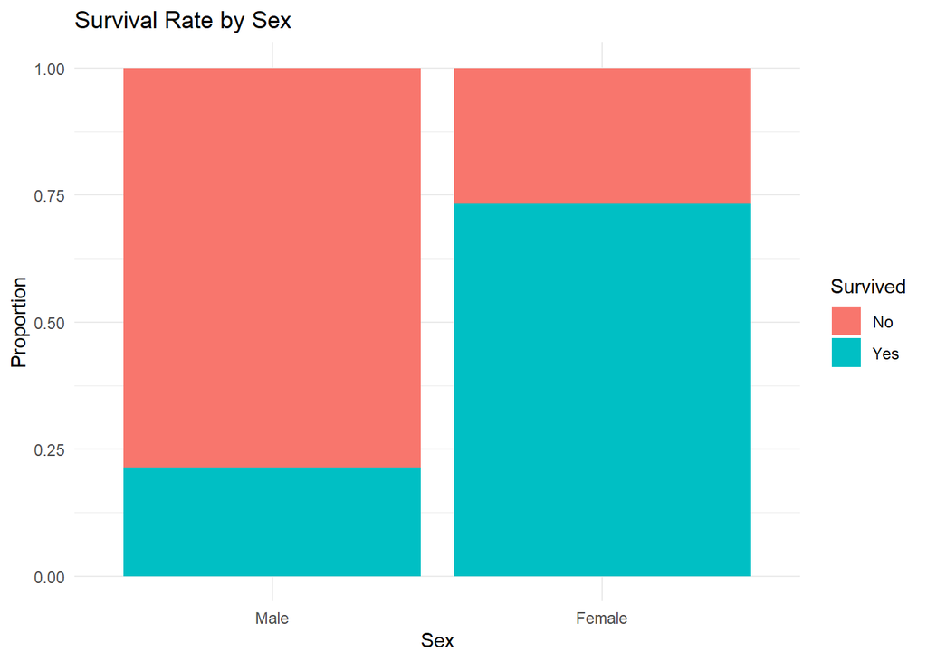

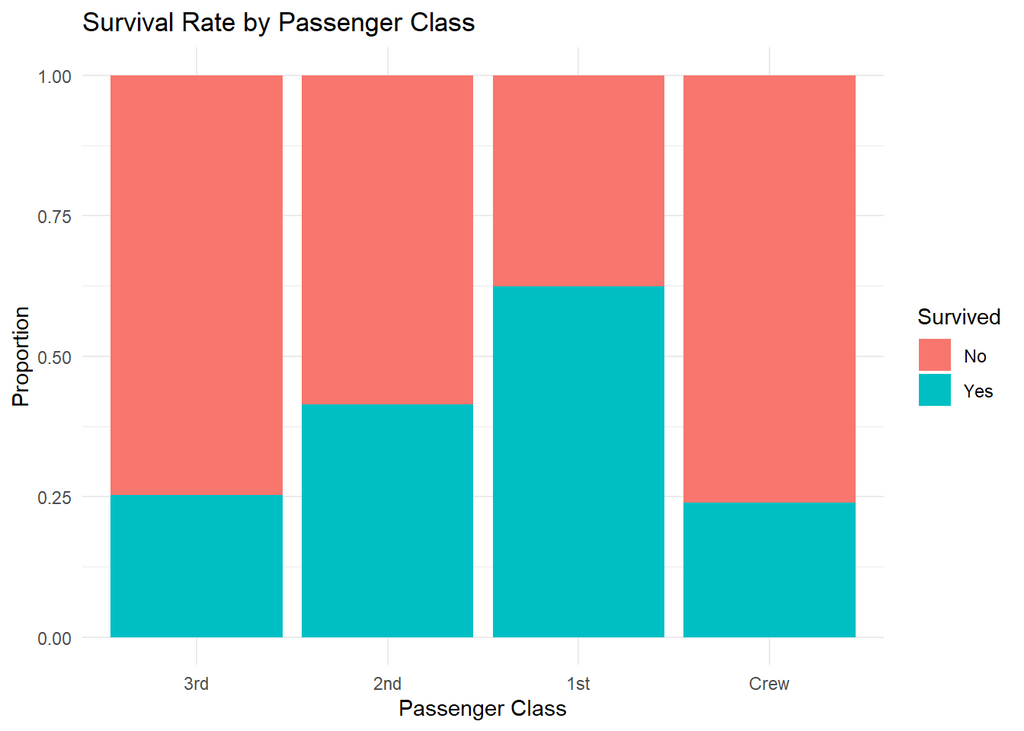

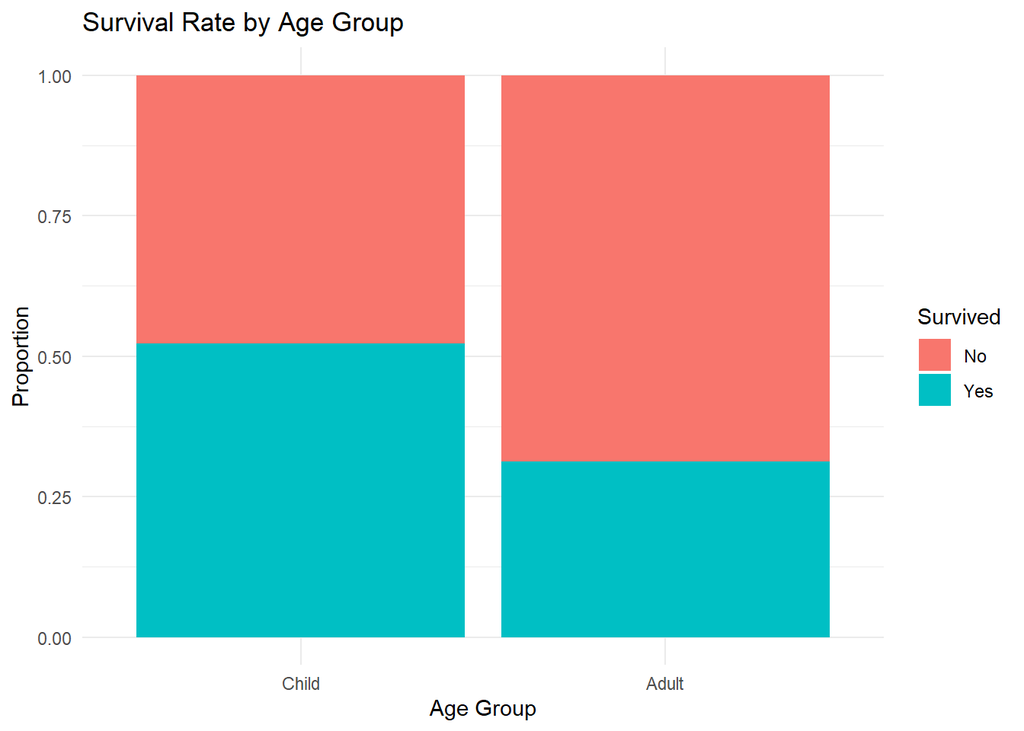

**Discussion Question 1:** Based on your exploration, what factors appear most strongly related to survival? Why might these patterns have occurred historically?

*Answer: Sex appears to be the strongest predictor - females had a survival rate of 73.2% compared to males at 21.2%. Passenger class also matters significantly, with 1st class passengers having a survival rate of 62.5% and crew having the lowest at 24%. Age group shows children had a survival rate of 52.3% compared to adults at 31.3%. This reflects the “women and children first” protocol and the social stratification of 1912 society where higher-class passengers had priority access to lifeboats.*

## Part 2: Building Logistic Regression Models (12 minutes)

**Task 2.1:** Fit logistic regression models to predict survival:

- Model 1: Age group only
- Model 2: Age group and passenger class
- Model 3: All variables (sex, class, age group)

```
##
## Call:
## glm(formula = survived ~ sex + pclass + age_group, family = binomial,
##     data = titanic_data)
##
## Coefficients:
##                Estimate Std. Error z value Pr(>|z|)
## (Intercept)     0.04096    0.26448   0.155   0.8769
## sexFemale       2.05802    0.12604  16.328  < 2e-16 ***
## pclass         -0.27834    0.05047  -5.515 3.48e-08 ***
## age_groupAdult -0.51147    0.22292  -2.294   0.0218 *
## ---
## Signif. codes:  0 '***' 0.001 '**' 0.01 '*' 0.05 '.' 0.1 ' ' 1
##
## (Dispersion parameter for binomial family taken to be 1)
##
##     Null deviance: 2769.5  on 2200  degrees of freedom
## Residual deviance: 2299.2  on 2197  degrees of freedom
## AIC: 2307.2
##
## Number of Fisher Scoring iterations: 4
```

**Task 2.2:** Extract and interpret the coefficients.

```
## [1] "Full Model Coefficients:"
```

```
## # A tibble: 4 × 6
##   term           estimate std.error statistic  p.value odds_ratio
##   <chr>             <dbl>     <dbl>     <dbl>    <dbl>      <dbl>
## 1 (Intercept)      0.0410    0.264      0.155 8.77e- 1      1.04
## 2 sexFemale        2.06      0.126     16.3   6.20e-60      7.83
## 3 pclass          -0.278     0.0505    -5.52  3.48e- 8      0.757
## 4 age_groupAdult  -0.511     0.223     -2.29  2.18e- 2      0.600
```

**Discussion Question 2:**

- Interpret the odds ratio for sex (Female vs Male) in practical terms.
- How do the different passenger classes compare in terms of survival odds?
- Which variables are statistically significant in the full model?

*Answers:*

- Females have odds of survival that are about 7.83 times the odds of males - meaning females were much more likely to survive than males.
- Each increase in passenger class number (moving from 1st to 2nd to 3rd to crew) decreases survival odds by a factor of about 0.76.
- sexFemale, pclass, age_groupAdult are statistically significant predictors (p < 0.05).

## Part 3: Model Predictions and Performance (12 minutes)

**Task 3.1:** Generate predictions and add them to your dataset.

```
##     sex pclass_factor age_group survived  prob_age prob_age_class prob_full
## 1  Male           3rd     Child        0 0.5229358      0.4800136 0.3112944
## 2  Male           3rd     Child        0 0.5229358      0.4800136 0.3112944
## 3  Male           3rd     Child        0 0.5229358      0.4800136 0.3112944
## 4  Male           3rd     Child        0 0.5229358      0.4800136 0.3112944
## 5  Male           3rd     Child        0 0.5229358      0.4800136 0.3112944
## 6  Male           3rd     Child        0 0.5229358      0.4800136 0.3112944
## 7  Male           3rd     Child        0 0.5229358      0.4800136 0.3112944
## 8  Male           3rd     Child        0 0.5229358      0.4800136 0.3112944
## 9  Male           3rd     Child        0 0.5229358      0.4800136 0.3112944
## 10 Male           3rd     Child        0 0.5229358      0.4800136 0.3112944
```

**Task 3.2:** Convert probabilities to classifications and evaluate performance.

```
##    accuracy precision     recall specificity  f1_score       model
## 1 0.6792367 0.5229358 0.08016878   0.9651007 0.1390244    Age Only
## 2 0.7246706 0.6504298 0.31926864   0.9181208 0.4283019 Age + Class
## 3 0.7760109 0.7319149 0.48382560   0.9154362 0.5825572  Full Model
```

```
## [1] "Confusion Matrix - Full Model:"
```

```
##          Actual
## Predicted    0    1
##         0 1364  367
##         1  126  344
```

**Task 3.3:** Identify which passengers your model struggles to classify correctly.

```
## [1] "Total misclassified passengers: 493"
```

```
## [1] "Most common misclassification patterns:"
```

```
## # A tibble: 8 × 5
##   sex    pclass_factor survived count avg_prob
##   <fct>  <fct>            <dbl> <int>    <dbl>
## 1 Male   Crew                 1   192    0.170
## 2 Female 3rd                  0   106    0.696
## 3 Male   3rd                  1    88    0.228
## 4 Male   1st                  1    62    0.331
## 5 Male   2nd                  1    25    0.312
## 6 Female 2nd                  0    13    0.737
## 7 Female 1st                  0     4    0.787
## 8 Female Crew                 0     3    0.616
```

**Task 3.4:** Create historical passenger profiles.

```
## [1] "Historical Passenger Survival Probabilities:"
```

```
##                description survival_prob
## 1 First-class adult female     0.7873727
## 2   Third-class adult male     0.2132326
## 3       Second-class child     0.3738512
## 4              Crew member     0.1702447
```

**Discussion Question 3:**

- Which model performs best? Why?
- What types of passengers does your model misclassify most often?
- Can you think of historical reasons why these misclassifications might occur?
- Looking at your historical passenger profiles, what do the survival probabilities tell us about social dynamics on the Titanic?

*Answers:*

- The full model performs best with an accuracy of 77.6% and F1 score of 58.3%. The Age + Class model shows improvement over Age Only, demonstrating how adding passenger class enhances predictive power.
- The model most often misclassifies Male passengers in Crew class and some females who died despite high predicted survival probability.
- Historical reasons for misclassification could include: proximity to lifeboats, helping others, individual circumstances not captured in the data, or exceptions to the “women and children first” protocol.
- The passenger profiles show stark social stratification: 1st class female (79% survival), 2nd class male child (37%), 3rd class male (21%), crew member (17%). This reflects both gender bias and class privilege in 1912 society.

## Part 4: ROC Analysis (8 minutes)

**Task 4.1:** Create ROC curves and calculate AUC.

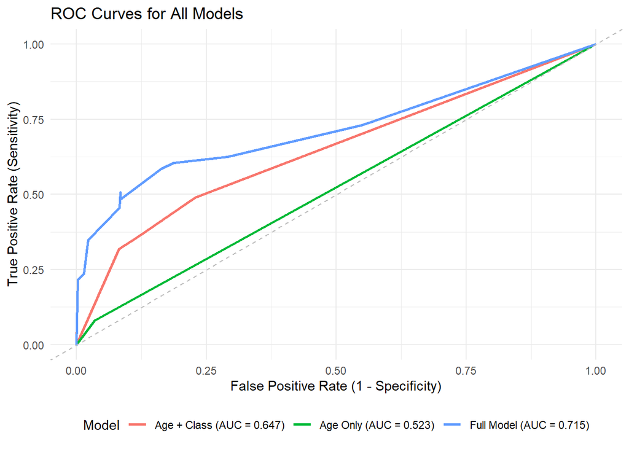

```
## AUC Values:
```

```
## Age Only: 0.523
```

```
## Age + Class: 0.647
```

```
## Full Model: 0.715
```

**Discussion Question 4:** Looking at your ROC curves:

1. **Model Performance:** Which model has the highest AUC? What does this tell you about its ability to distinguish survivors from non-survivors?
2. **ROC Interpretation:** How does your best model’s ROC curve compare to the diagonal line (random classifier)? What does the area under the curve represent?
3. **Performance Trade-offs:** Looking at your precision, recall, and F1 scores, how well does your model balance between correctly identifying survivors vs. avoiding false alarms?
4. **Historical Context:** If this model were used to prioritize lifeboat access, what would be the human cost of false positives vs. false negatives?

## Part 5: Reflection and Extension (Bonus)

**Task 5.1:** Compare your logistic regression to simple rules.

```
## Simple Rule Accuracies:
```

```
## Rule 1 (All children survive): 0.679
```

```
## Rule 2 (First-class survive): 0.714
```

```
## Full Logistic Model: 0.776
```

**Discussion Questions:**

1. **Model Insights:** What did logistic regression reveal about Titanic survival that simple rules missed?

*Answer: Logistic regression revealed the combined effects of multiple factors and their relative importance. The progression from Age Only (AUC = 0.523) → Age + Class (AUC = 0.647) → Full Model (AUC = 0.715) shows how adding variables systematically improves prediction. Age alone is relatively weak, but combining it with class improves performance, and adding sex creates the strongest model. The analysis captures nuanced interactions that simple rules miss.*

2. **Ethical Considerations:** How might predictive models like this be misused if applied to modern emergency situations?

*Answer: Such models could reinforce existing biases, create unfair prioritization systems, or be used to justify discrimination. They might overlook individual circumstances or lead to algorithmic decision-making that lacks human compassion and flexibility.*

3. **Historical Analysis:** How could this type of analysis help historians understand social dynamics in 1912?

*Answer: The analysis quantifies social hierarchies and reveals how formal and informal rules about gender, class, and age operated under extreme circumstances. It provides empirical evidence for social stratification in Edwardian society.*

4. **Model Improvements:** If you had additional data (like exact location on ship, family relationships, etc.), how might it improve your predictions?

*Answer: Additional data could capture proximity to lifeboats, family dynamics (staying together vs. separating), individual health/mobility, crew behavior, and specific circumstances during evacuation. This would likely improve prediction accuracy significantly.*

## Bonus Questions

Once you’ve completed the main activity, try these additional challenges:

**Bonus 1: Historical Context Analysis**

Analyze whether your model supports historical accounts like “women and children first” and the impact of social class. What does the data reveal about society in 1912?

```
## # A tibble: 2 × 3
##   women_or_child survival_rate count
##   <chr>                  <dbl> <int>
## 1 No                     0.203  1667
## 2 Yes                    0.699   534
```

```
## [1] "Chi-square p-value for sex vs survival: 0"
```

**Bonus 2: Feature Engineering**

Create a new variable called `family_size` or `title_from_name` and see if it improves your model. How might family relationships have affected survival chances?

**Bonus 3: Interaction Effects**

Test if there are interaction effects between sex and passenger class. Did the “women and children first” rule apply equally across all social classes?

```
## AIC Comparison:
```

```
## Additive Model: 2307.211
```

```
## Interaction Model: 2241.605
```

```
## # A tibble: 5 × 6
##   term             estimate std.error statistic  p.value odds_ratio
##   <chr>               <dbl>     <dbl>     <dbl>    <dbl>      <dbl>
## 1 (Intercept)       -0.431     0.273      -1.58 1.15e- 1      0.650
## 2 sexFemale          5.17      0.468      11.1  1.94e-28    177.
## 3 pclass            -0.0734    0.0587     -1.25 2.11e- 1      0.929
## 4 age_groupAdult    -0.680     0.222      -3.07 2.15e- 3      0.507
## 5 sexFemale:pclass  -1.21      0.166      -7.27 3.61e-13      0.299
```

**Bonus 4: Alternative Thresholds for Historical Decision-Making**

If you were the ship’s officer deciding who gets priority for lifeboats based on your model:

- What threshold would you use if lifeboats could save 30% of passengers?
- What threshold would you use if lifeboats could save 50% of passengers?
- How do these decisions change the types of passengers saved?

```
## Threshold for saving 30% of passengers: 0.321
```

```
## Threshold for saving 50% of passengers: 0.213
```

```
##
## Demographics of passengers saved at 30% threshold:
```

```
## # A tibble: 6 × 3
##   sex    pclass_factor count
##   <fct>  <fct>         <int>
## 1 Female 3rd             196
## 2 Female 1st             145
## 3 Female 2nd             106
## 4 Female Crew             23
## 5 Male   2nd              11
## 6 Male   1st               5
```

```
##
## Demographics of passengers saved at 50% threshold:
```

```
## # A tibble: 7 × 3
##   sex    pclass_factor count
##   <fct>  <fct>         <int>
## 1 Female 3rd             196
## 2 Male   1st             180
## 3 Male   2nd             179
## 4 Female 1st             145
## 5 Female 2nd             106
## 6 Male   3rd              48
## 7 Female Crew             23
```